# sheet_1_ex_1

2023-10-09

## Introduction

In the first lecture of this course we got introduced to a study about the **adverse effects of valporic acid on neurological functionality in embryos during pregnancy** (Kurg. A.K. et. a, (2013)). Valporic acid is typically used for treatment of epilepsy, migraines, headaches and even specific types of mental illnesses as a mood stabilizer. However, according to the World Health Organization, it is strongly advised to not take this medication during pregnancy as it bears a high risk of developmental disorders (more information, like if you have literally nothing else to do here). The study has been done in vitro (in petri dishes) on (multiplied) embryonic stem cells. As the **response-data** we therefore use **gen-expressions, ranging from 2 to 14**. Beside the **6 negative controls** we have seen **7 response-dosages on 3 samples each**.

## Requirements

As part of this analysis, we are using tidyverse (especially ggplot).

```r
library(tidyverse)
library(gridExtra)
```

## Importing the data

To import the data we use the `load()` function. Make sure to have the right working directory, when importing the data.

```r
# use the setwd(...) function if necessary.
load("./data/VPAData-Random.Rda")
head(randomVPA)
```

```
##            UKN1_sat_c_untr_D12_25NS_168.CEL UKN1_sat_c_untr_D12_26NS_169.CEL
## 1565889_at                         4.153705                         5.406904
## 223665_at                          5.733846                         5.465620
## 236987_at                          5.462292                         5.253679
## 1562275_at                         6.577935                         6.828268
## 212321_at                          8.692530                         8.760785
## 242121_at                          8.951760                         9.276004
##            UKN1_sat_c_untr_D12_27NS_170.CEL UKN1_sat_c_untr_D12_25NS_165.CEL
## 1565889_at                         5.118860                         4.757236
## 223665_at                          5.408087                         5.740397
## 236987_at                          5.239495                         5.305157
## 1562275_at                         6.915521                         6.623449
## 212321_at                          8.698421                         8.675030
## 242121_at                          9.159183                         9.522171
##            UKN1_sat_c_untr_D12_26NS_166.CEL UKN1_sat_c_untr_D12_27NS_167.CEL
## 1565889_at                         5.863943                         4.869197
## 223665_at                          5.901340                         4.791167
## 236987_at                          5.298510                         5.386475
## 1562275_at                         6.827734                         6.468019
## 212321_at                          9.002387                         8.579736
## 242121_at                          9.507261                         9.303295
##            UKN1_sat_c_VPA_25mM_D12_25NS_162.CEL
## 1565889_at                             4.922289
## 223665_at                              5.693083
## 236987_at                              5.221779
## 1562275_at                             6.268896
## 212321_at                              8.738063
## 242121_at                              9.443138
##            UKN1_sat_c_VPA_25mM_D12_26NS_163.CEL
## 1565889_at                             4.760783
## 223665_at                              5.456103
## 236987_at                              5.420433
## 1562275_at                             6.314210
## 212321_at                              8.675803
## 242121_at                              9.062589
##            UKN1_sat_c_VPA_25mM_D12_27NS_164.CEL
## 1565889_at                             5.627425
## 223665_at                              5.865763
## 236987_at                              5.415289
## 1562275_at                             6.412776
```

[output cut: 113 more lines]

```
## 242121_at                                9.176371
##            UKN1_sat_c_VPA_1000mM_D12_26NS_142.CEL
## 1565889_at                               3.220457
## 223665_at                                5.966479
## 236987_at                                6.513544
## 1562275_at                               5.787243
## 212321_at                                7.747895
## 242121_at                                7.596173
##            UKN1_sat_c_VPA_1000mM_D12_27NS_143.CEL
## 1565889_at                               3.551020
## 223665_at                                4.882104
## 236987_at                                6.332340
## 1562275_at                               6.182750
## 212321_at                                7.910297
## 242121_at                                8.398055
```

We will refactor the data to have an easier time with the given tasks:

```r
# we will create the variables for gen expression, sample_id, concentration and gen id
# length of the data
n <- 27*500
data <- data.frame(gen_exp = rep(NA, n),
                   gen_id = rep(1:500, 27),
                   concentration = rep(NA, n),
                   sample_id = rep(NA, n))

# this part of the code is very slow and cheap. Feel free to find a more elegant solution
response_dose <- c(25, 150, 350, 450, 550, 800, 1000)

data$concentration[1:(6*500)] <- 0

for (i in 1:7) {
  lower_bound <- 6*500 + (i-1)*1500
  upper_bound <- 6*500 + i*1500
  data$concentration[lower_bound:upper_bound] <- response_dose[i]
}

sample_ids <- factor(as.character(1:27),
                     levels = as.character(1:27))

for (i in 1:27) {
  data$sample_id[((i-1)*500):(i*500)] <- sample_ids[i]
  for (j in 1:500) {
    coordinate_to_row <- (i-1)*500 + j
    data$gen_exp[coordinate_to_row] <- randomVPA[j,i]

  }
}
```

## Boxplot from the lecture

The plot from the lecture will be realized using ggplot2

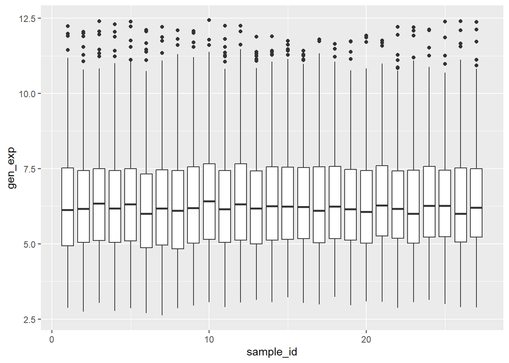

```r
data %>%
  ggplot(aes(y = gen_exp, x = sample_id, group = sample_id)) +
  geom_boxplot()
```

## Variance of genes after response-dosage

```r
# using new data set
var_data <- data %>%
  group_by(gen_id, concentration) %>%
  summarise(var_gen_exp = sd(gen_exp)) %>%
  unique()
```

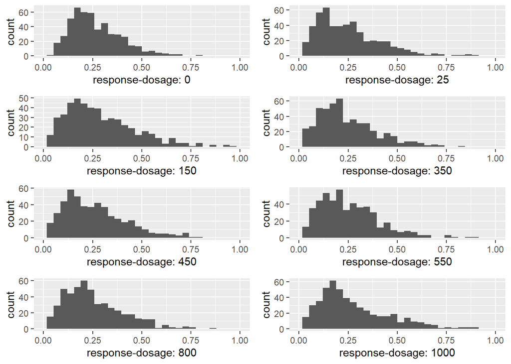

```r
# histograms by concentration
for (i in 1:8) {
  plot_name <- paste("hist_plot_", i,
                     sep = "")
  # filtering data and creating a fitting x label
  if (i == 1) {
    plot_data <- var_data %>%
      filter(concentration == 0)
    plot_x_label <- paste("response-dosage:", 0)
  } else {
    plot_data <- var_data %>%
      filter(concentration == response_dose[i-1])
    plot_x_label <- paste("response-dosage:", response_dose[i-1])
  }

  # creating a plot and assigning it a name
  assign(plot_name,
         plot_data %>%
           ggplot(aes(x = var_gen_exp)) +
           geom_histogram() +
           xlim(0,1) +
           xlab(plot_x_label))
}
grid.arrange(hist_plot_1,
             hist_plot_2,
             hist_plot_3,
             hist_plot_4,
             hist_plot_5,
             hist_plot_6,
             hist_plot_7,
             hist_plot_8,
             ncol = 2
             )
```

## Ploting the gene profiles with the highest variance

For this we are going to use `var_data` again

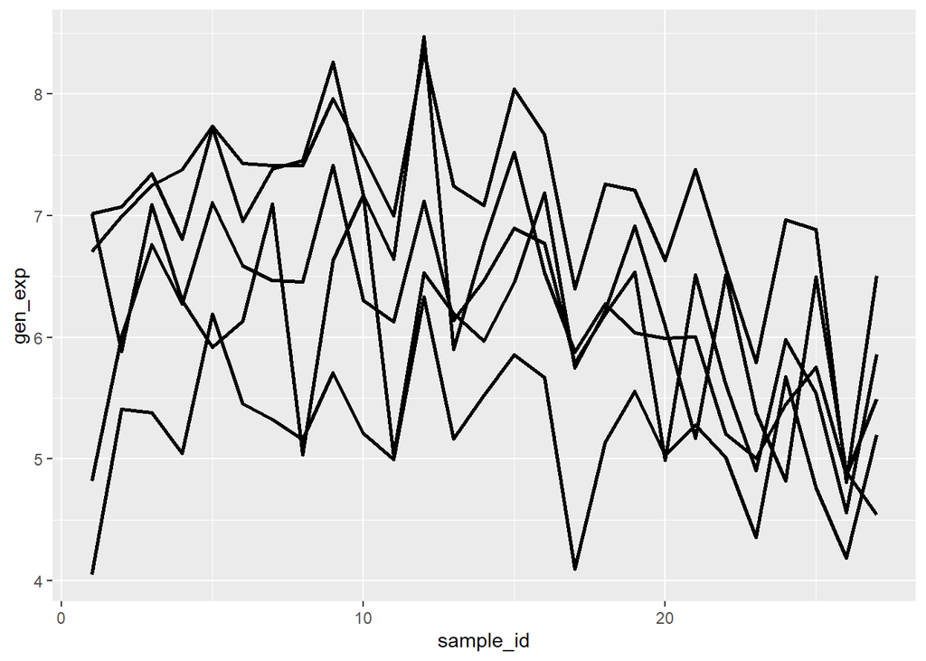

```r
# finding the max values after concentration
max_var_data <- var_data %>%
  group_by(concentration) %>%
  summarise(max_var = max(var_gen_exp),
            # find the gen id that corresponds to the maximum value
            gen_id = gen_id[which(var_gen_exp == max(var_gen_exp))]) %>%
  unique()

# inner join with processed data
max_var_plot_data <- data %>%
  filter(gen_id %in% max_var_data$gen_id)

# plotting
max_var_plot_data %>% ggplot(aes(x = sample_id,
                                 y = gen_exp,
                                 group = gen_id)) +
  geom_line(size = 1)
```

afterwards we are going to repeat the same procedure for min values:

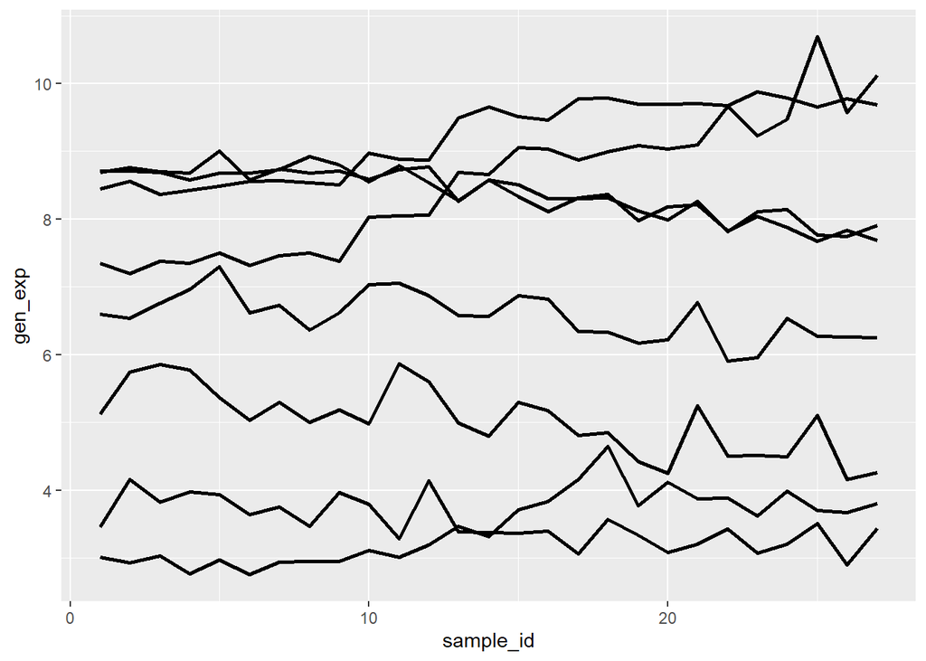

```r
# finding the max values after concentration
min_var_data <- var_data %>%
  group_by(concentration) %>%
  summarise(min_var = min(var_gen_exp),
            # find the gen id that corresponds to the maximum value
            gen_id = gen_id[which(var_gen_exp == min(var_gen_exp))]) %>%
  unique()

# inner join with processed data
min_var_plot_data <- data %>%
  filter(gen_id %in% min_var_data$gen_id)

# plotting
min_var_plot_data %>% ggplot(aes(x = sample_id,
                                 y = gen_exp,
                                 group = gen_id)) +
  geom_line(size = 1)
```